# A1 submission

Carlo Jean 27858308

2024

# Preliminary steps

```r
main_data <- read.csv("A1_data.csv", header = TRUE, stringsAsFactors = TRUE)
set.seed(8)
index <- sample(1:1000, size = 900 , replace = FALSE)
test_data <- main_data[index,]
test_data <- test_data %>% arrange(ID)
knitr::kable(test_data[c(1,100,200,500),] %>% select(ID))
```

|  | ID |
| --- | --- |
| 1 | 3 |
| 100 | 114 |
| 200 | 231 |
| 500 | 562 |

A random sample of 900 observations was taken from the data to work with for the project. A seed of “8” was used and then the sample was sorted in ascending order based on the “ID” variable. Index “1”, “100”, “200” and “500” were then produced to cross-check SUNLearn to verify the integrity of the data

# Questions

### Question 1

##### Question 1.1

```r
#mean of AMOUNT variable
mean(test_data$AMOUNT)
```

```
## [1] 99823.11
```

##### Question 1.2

```r
#median of AMOUNT variable
median(test_data$AMOUNT)
```

```
## [1] 70850
```

### Question 2

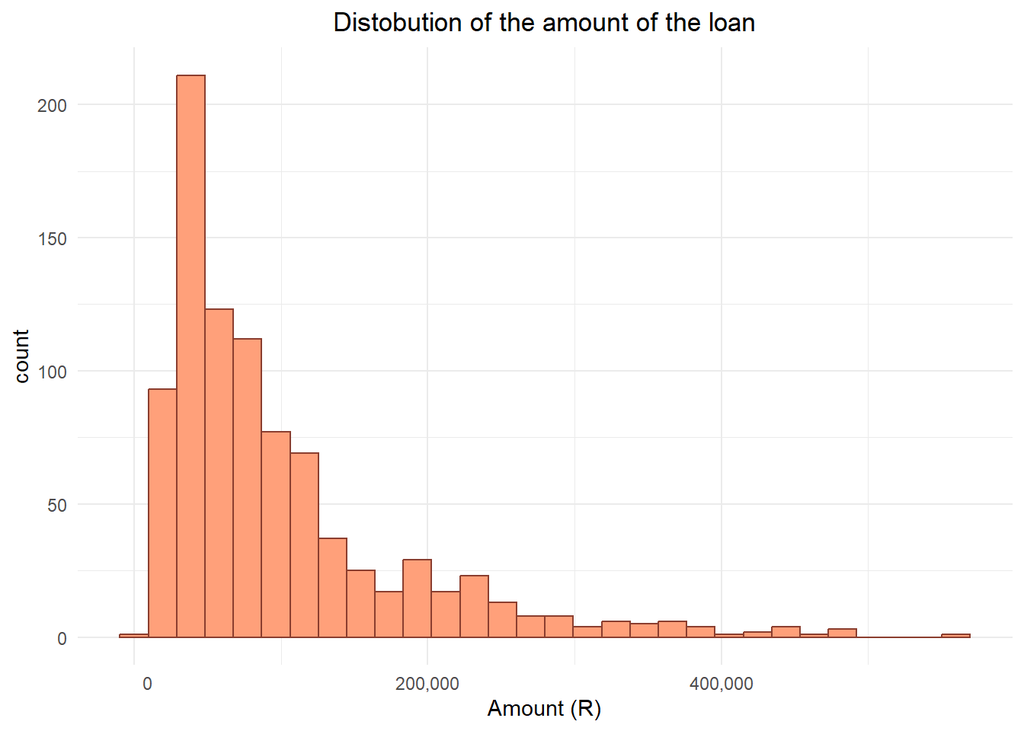

```r
#plot
ggplot(test_data) +
  geom_histogram(aes(AMOUNT), fill = "lightsalmon", color = "coral4") +
  theme_minimal() +
  scale_x_continuous(name = "Amount (R)", labels = marks_no_sci) +
  labs(title = "Distobution of the amount of the loan") +
  theme(plot.title = element_text(hjust = 0.5))
```

As seen by the shape of the plot above as well as the fact that the mean value of 99823.11 is larger than the median value of 70850 (as calculated above), we can confidently say that the distribution of the AMOUNT variable is positively skewed.

### Question 3

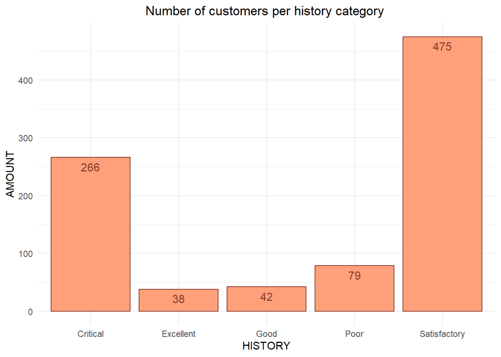

```r
#plot
ggplot(amount) +
  geom_bar(aes(x = HISTORY, y = `n()`)
    ,stat = "identity", fill = "lightsalmon"
    ,color = "coral4") +
  theme_minimal()  +
  geom_text(aes(label = `n()`, x = HISTORY, y=`n()`)
    ,vjust=1.6, color="coral4", size=4) +
  labs(y = "AMOUNT", title = "Number of customers per history category "
    ,x = "HISTORY") +
  theme(plot.title = element_text(hjust = 0.5))
```

### Question 4

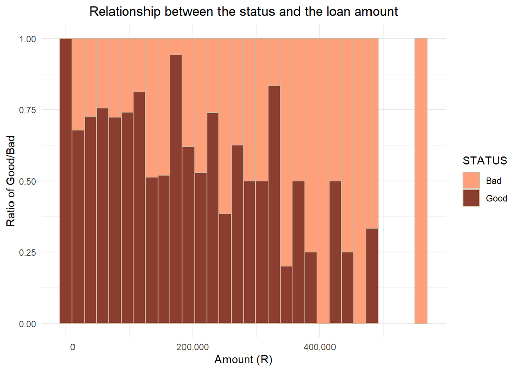

```r
#plot
ggplot(test_data)+
  geom_histogram(aes(x = AMOUNT,fill = STATUS)
    , position = "fill", color = 'bisque3')+
  theme_minimal() +
  scale_x_continuous(name = "Amount (R)", labels = marks_no_sci) +
  labs(title = "Relationship between the status and the loan amount"
    , y = "Ratio of Good/Bad") +
  theme(plot.title = element_text(hjust = 0.5))+
  scale_fill_manual(values = c('#FFA07A','#8B3E2F'))
```

There seems to be a moderate to weak relationship between the status of the customer and the amount of the loan they received.

### Question 5

##### Question 5.1

```r
#correlation between amount and duration
round(cor(test_data$DURATION,test_data$AMOUNT),digits = 3)
```

```
## [1] 0.628
```

##### Question 5.2

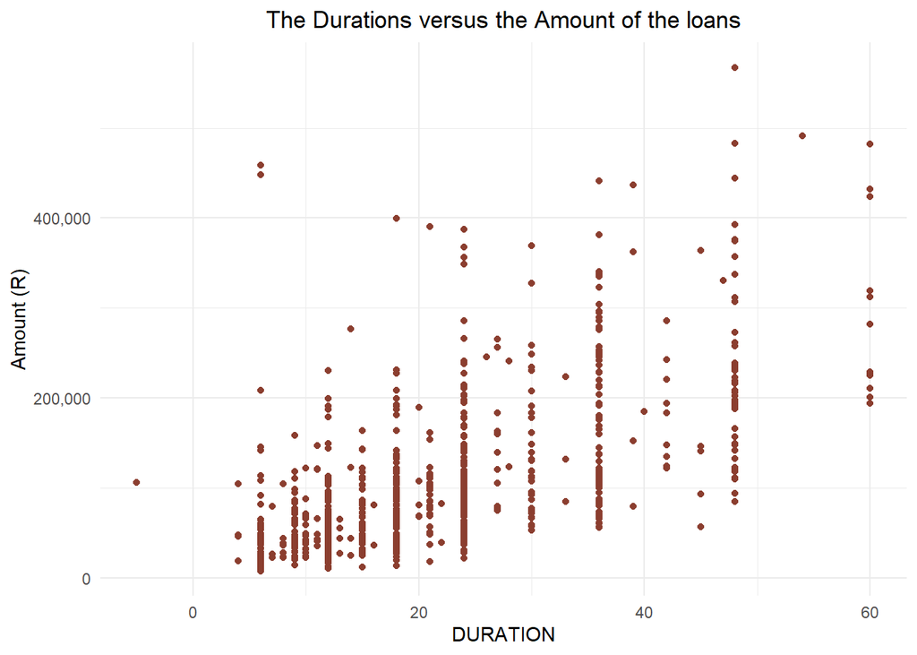

```r
#plot
ggplot(test_data)+
  geom_point(mapping = aes(x = DURATION, y = AMOUNT),color = 'coral4') +
  theme_minimal() +
  labs(title = "The Durations versus the Amount of the loans") +
  scale_y_continuous(name = "Amount (R)", labels = marks_no_sci) +
  theme(plot.title = element_text(hjust = 0.5))
```

```r
#correction of data
new_test_data = filter(test_data,DURATION > 0)

#recalculation of correlation
round(cor(new_test_data$DURATION,new_test_data$AMOUNT),digits = 3)
```

```
## [1] 0.629
```

In the plot above we can see that there is a usual observation (duration = -5). It is impossible to have a negative duration, as that would imply that you needed to pay your loan 5 years before the loan even started. I have there for removed the observation and recalculated the correlation between DURATION and AMOUNT to be 0.629

### Question 6

```r
#printing of table
knitr::kable((purpose_data %>% group_by("Purpose" = COMB_PURPOSE)
              %>% summarise("Number of loans" = n(),
                            "Average loan amount" = mean(AMOUNT))))
```

| Purpose | Number of loans | Average loan amount |
| --- | --- | --- |
| business | 92 | 129361.96 |
| Cars | 303 | 117653.80 |
| Household content | 422 | 81198.10 |
| education | 53 | 80586.79 |
| other | 10 | 209060.00 |
| repairs | 20 | 83155.00 |

The average loan for the different categories seems to be relatively grouped into 3 different ranges. “Household content”, “education” and “repairs” all being ± R80 000 and both “business” and “Cars” being ± R120 000. “other” is the final range but despite being the smallest category (10 loans) it has the largest average loan amount of ± R200 000.

The first range of ± R80 000 appears to be inline with the types of objects that every person will need regardless of their social class and therefore it is on average a lot lower amounts. The second range of ± R120 000 is the more middle class seeing as not everyone will have the financial ability to buy a car for themselves or open their own business. The third range of ± R200 000 appears to be objects that are not being financed regularly enough to have their own category and are thereby likely to be things only a very small amount of people can afford.

It is however only speculative as these variables by themselves are not enough to make a prediction with accuracy.

### Question 7

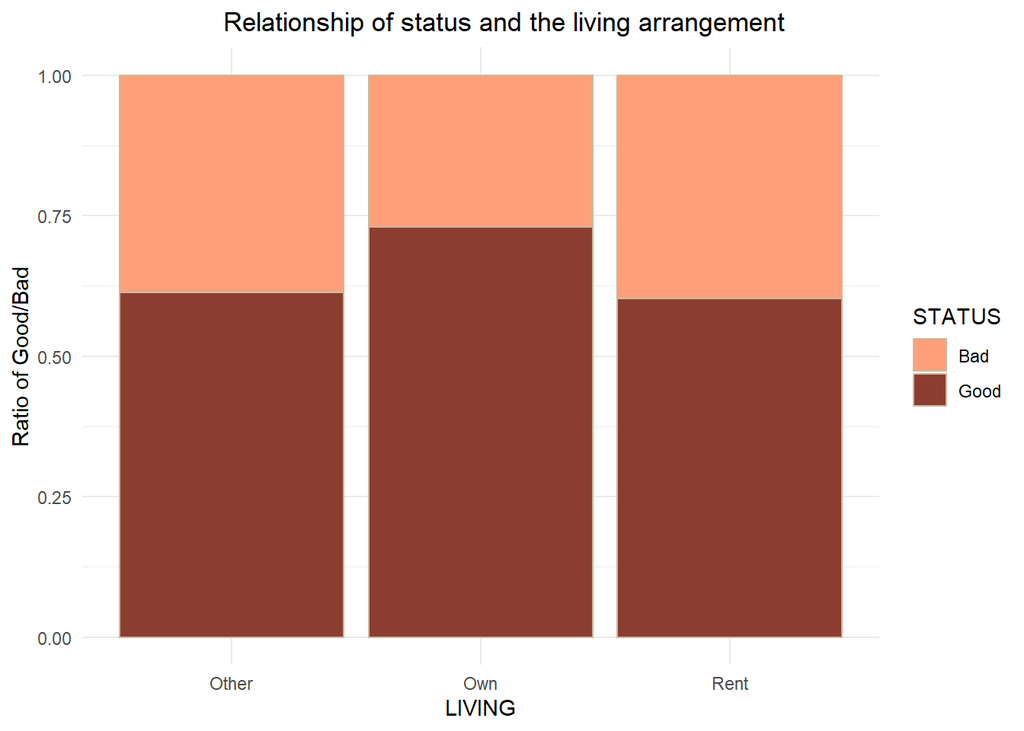

```r
#plot
ggplot(test_data)+
  geom_bar(mapping = aes(x = LIVING, fill = STATUS), position = "fill", color = 'bisque3')+
  theme_minimal() +
  labs(title = "Relationship of status and the living arrangement"
    , y = "Ratio of Good/Bad") +
  theme(plot.title = element_text(hjust = 0.6))+
  scale_fill_manual(values = c('#FFA07A','#8B3E2F'))
```

### Question 8

###### Question 8.1

```r
#amount with missing values
count(filter(test_data,CURRENT == "" | SAVINGS == ""))[1,]
```

```
## [1] 428
```

###### Question 8.2

```r
#creation of new variable
test_data <- mutate(test_data,MORE_LOANS = case_when(NUMPROD > 1 ~ "Yes", NUMPROD <= 1 ~ "No"))
count(filter(test_data, MORE_LOANS == "Yes"))[1,]
```

```
## [1] 338
```

##### Question 8.3

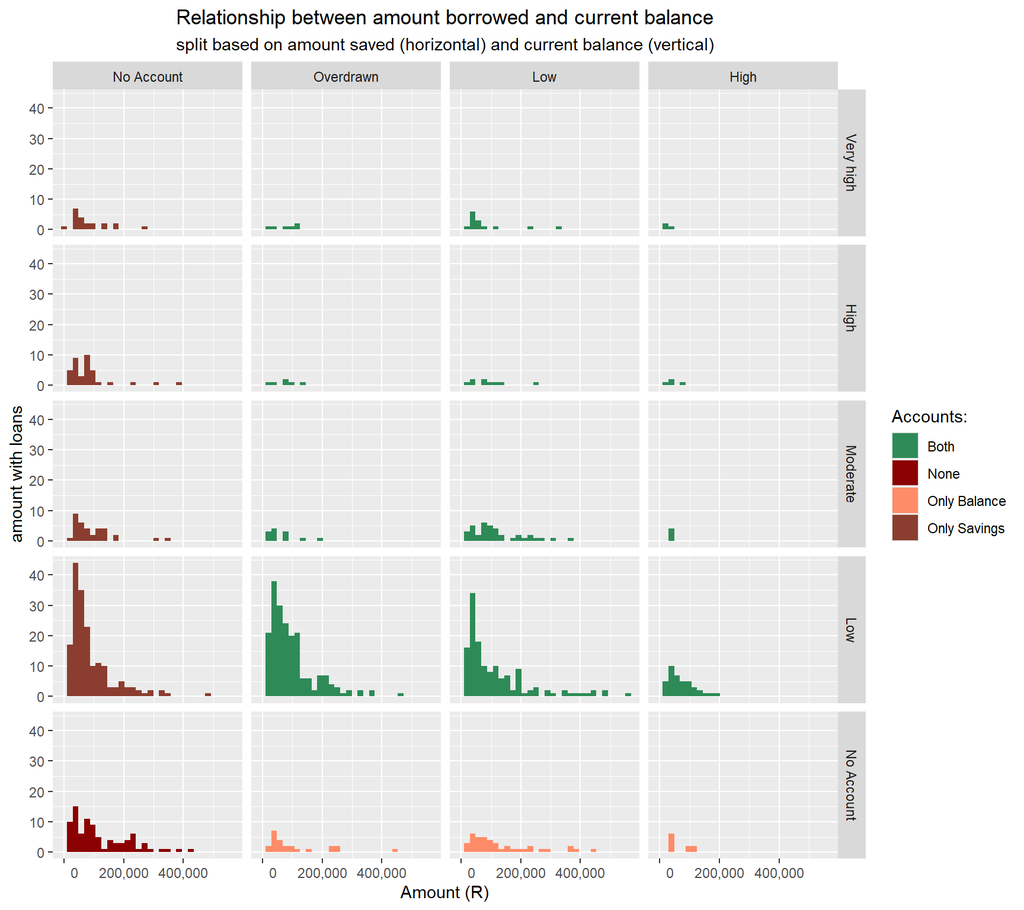

```r
#plot
ggplot(borrowed_savings) +
  geom_histogram(mapping = aes(AMOUNT, fill = NO_ACCOUNT), position = 'stack') +
  facet_grid(SAVINGS ~ CURRENT, labeller = labeller(SAVINGS = label_value,
                                                    CURRENT = label_value))+
  scale_x_continuous(name = "Amount (R)", labels = marks_no_sci) +
  labs(title = "Relationship between amount borrowed and current balance"
    , y = "amount with loans",
    subtitle = "split based on amount saved (horizontal) and current balance (vertical)",
    fill = "Accounts:") +
  theme(plot.title = element_text(hjust = 0.5),
        plot.subtitle = element_text(hjust = 0.5)) +
  scale_fill_manual(values = c('seagreen','red4','salmon1','coral4'))
```

###### *table 1 - current balance*

Current Balance

| CURRENT | Mean_Amount | count |
| --- | --- | --- |
| No Account | 96789.83 | 354 |
| Overdrawn | 95497.96 | 245 |
| Low | 117513.75 | 240 |
| High | 65195.08 | 61 |

```
## [1] "Spread percentage: 9.35%"
```

###### *table 2 - savings*

Savings Amount

| SAVINGS | Mean_Amount | count |
| --- | --- | --- |
| Low | 97877.40 | 553 |
| No Account | 118798.12 | 160 |
| Moderate | 99254.02 | 87 |
| High | 81867.86 | 56 |
| Very high | 79254.55 | 44 |

```
## [1] "Spread percentage: 7.06%"
```

There appears to a relationship between the amount of the loan and the client’s savings and/or current balance. As seen by the graph and the tables, people with less money (savings or current) by average tend to take out large loans. However this is not as significant as one may have thought. While as seen in Tables 1 and 2 there is a relationship between the amount and the status of the account, the spread percentage of the entire range of loans captured is 7.06% for the savings accounts and 9.35% for the current balance. This suggest that these values are tightly group together relative to the entire range and this suggest that the relationship is a lot more limited than it appears. This is supported by the graph It can be seen that the peak (amount of loans in that amount) decreases from left to right and bottom to top, but not by very much. If we look at the amount of loans in each account category however we will see that the current balance does not appear to have such a large effect on who will get a loan seeing as the categories all have similar number of entries in them. Except for high which is a lot lower (this can be due to fewer data points on “High” clients but it generally supports the relationship of clients with more money who acquire loans less often). The saving accounts differ by a lot, with “Low” and “No account” clearly having a lot more client’s receiving loans. This can be seen on the graph as the bottom left of the graph has high peaks while the top right barely have any.

### Question 9

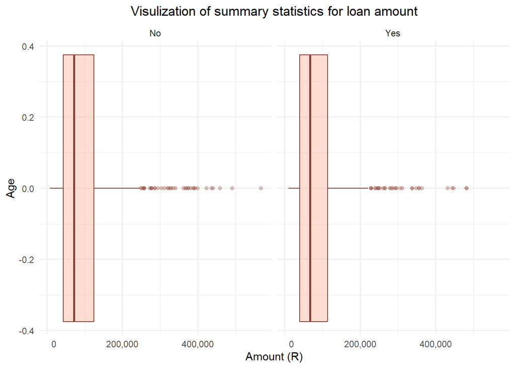

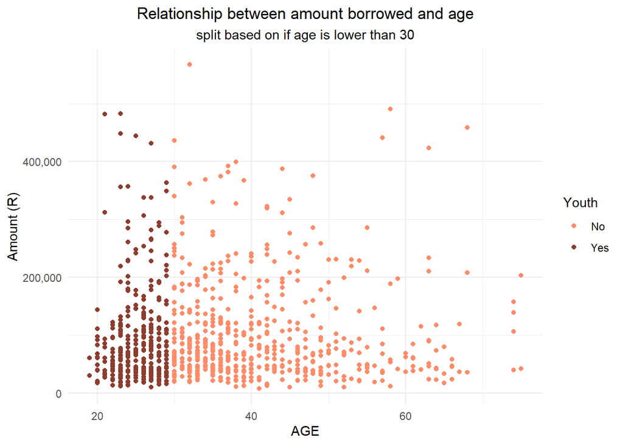

Summary Statistics for age lower than 30

|  | AMOUNT | AGE |
| --- | --- | --- |
|  | Min. : 10600 | Min. :19.00 |
|  | 1st Qu.: 39500 | 1st Qu.:23.00 |
|  | Median : 66800 | Median :25.00 |
|  | Mean : 95512 | Mean :25.19 |
|  | 3rd Qu.:113500 | 3rd Qu.:27.00 |
|  | Max. :482700 | Max. :29.00 |

Summary Statistics for age greater than 30

|  | AMOUNT | AGE |
| --- | --- | --- |
|  | Min. : 7700 | Min. :30.00 |
|  | 1st Qu.: 43400 | 1st Qu.:34.00 |
|  | Median : 71900 | Median :38.00 |
|  | Mean :102428 | Mean :41.45 |
|  | 3rd Qu.:124500 | 3rd Qu.:47.00 |
|  | Max. :567500 | Max. :75.00 |

```
## [1] "Youth correlation:  0.091        Non-Youth correlation:  -0.031"
```

```r
#plot
ggplot(age_amount)+
  geom_boxplot(aes(AMOUNT), alpha = 0.3, color = "coral4", fill = "salmon1") +
  facet_grid(.~Youth)+
  scale_x_continuous(name = "Amount (R)", labels = marks_no_sci) +
  theme_minimal() +
  labs(title = "Visulization of summary statistics for loan amount"
    , y = "Age",
    color = "Younger than 30:") +
  theme(plot.title = element_text(hjust = 0.5),
        plot.subtitle = element_text(hjust = 0.5)) +
  scale_color_manual(values = c('salmon1','coral4'))

#plot
ggplot(age_amount)+
  geom_point(mapping = aes(x = AGE, y = AMOUNT, color = Youth))+
  scale_y_continuous(name = "Amount (R)", labels = marks_no_sci) +
  theme_minimal() +
  labs(title = "Relationship between amount borrowed and age",
    subtitle = "split based on if age is lower than 30") +
  theme(plot.title = element_text(hjust = 0.5),
        plot.subtitle = element_text(hjust = 0.5)) +
  scale_color_manual(values = c('salmon1','coral4'))
```

When analyzing the summary statistic it can clearly be seen that youth does indeed have a lower mean amount for the loans (R95,512 against R 102,428 ) as well as a lower median (R66,800 against R71,900). This combined with the fact that the youth have a lower max amount of (R482,700 against R567,500), can it be clearly stated that youth tend to borrow smaller amounts of money compared to ages 30 plus. By looking at the box chart and the scatter plot we can see that the older group contains more outliers which suggest that the older clients tend to be more sporadic. The scatter plot appears to show a negative correlation between age and the loan amount, thereby suggesting the older you are the less you will borrow. This is misleading however once we dig deeper. When we calculate the correlation we get 0.091 for youth and -0.031 for the older clients. These values are so close to zero that they are considered to be to statistically insignificant to overrule any information we gained from the means and median values. Therefore no mathematically concrete conclusion can be drawn about the correlation between age and the amount of the loan but based on the summary statistic it can be stated that younger people do in fact tend to borrow lower amounts, with older clients having more variability in the amount they borrow.

### Question 10

```r
knitr::kable(Q10 %>%
  group_by(GENDER) %>%
  summarise(Single = sum(Single),
    Married = sum(Married),
    Widowed = sum(Widowed),
    Divorced = sum(Divorced),
    Separated = sum(Separated),
    Missing_Value = sum(Missing_Value)))
```

| GENDER | Single | Married | Widowed | Divorced | Separated | Missing_Value |
| --- | --- | --- | --- | --- | --- | --- |
|  | 497 | 0 | 0 | 0 | 0 | 0 |
| Female | 0 | 0 | 0 | 0 | 0 | 282 |
| Male | 0 | 79 | 0 | 42 | 0 | 0 |

After examining the data it seems that in all the cases the client’s gender was not entered it was assigned being single. No female has a marital status and the male clients were either assigned married or divorced.

### Question 11

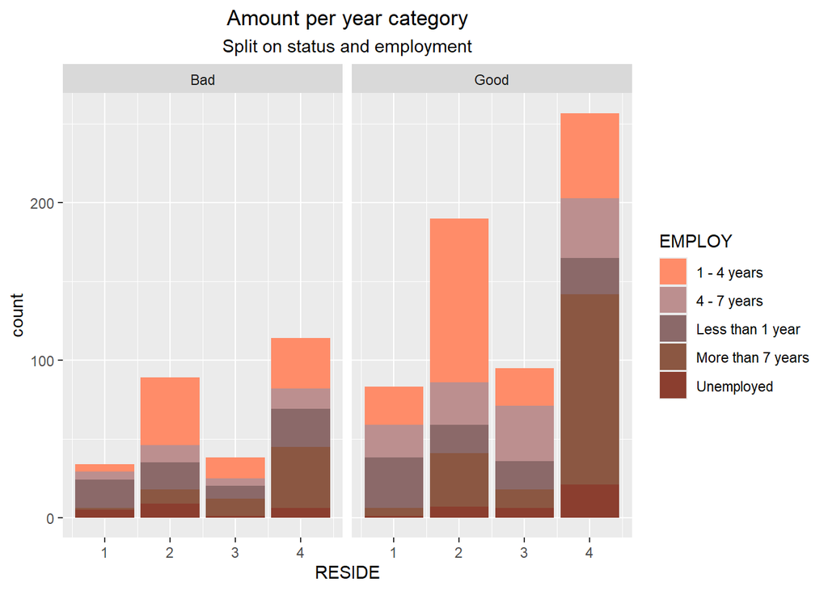

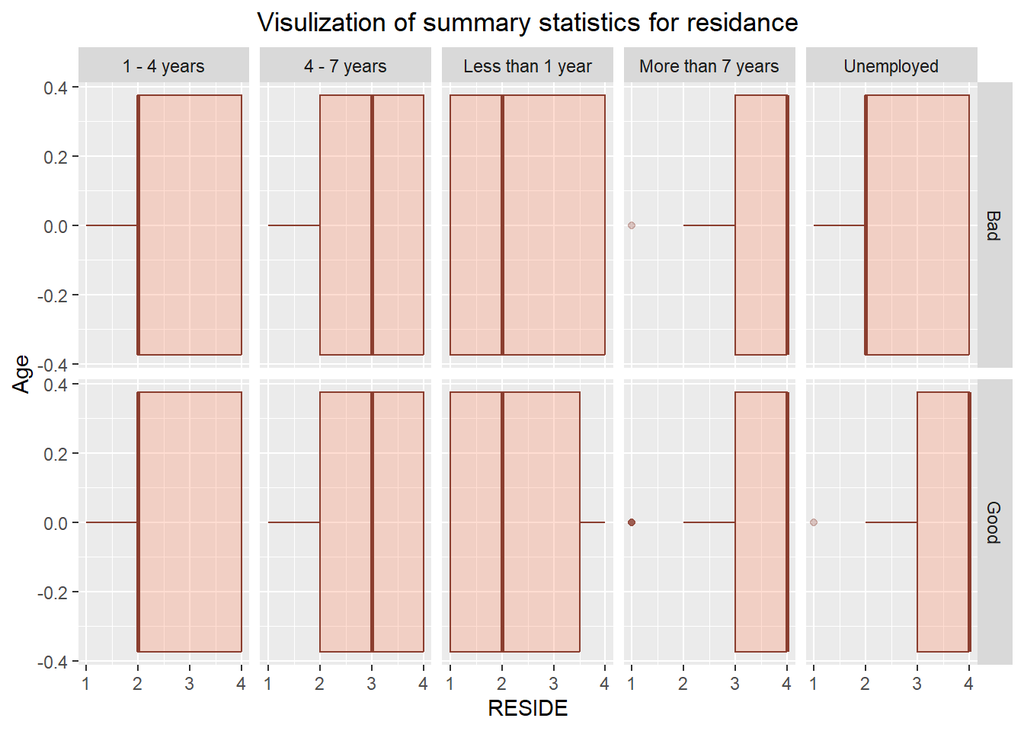

```r
Q11 <- test_data %>% select(RESIDE, EMPLOY, STATUS)

ggplot(Q11) +
  geom_bar(aes(RESIDE, fill = EMPLOY, color = RESIDE), position = 'stack')+
  facet_grid(.~STATUS) +
  scale_fill_manual(values =
                c('salmon1',"rosybrown","rosybrown4","lightsalmon4",'coral4'))+
  labs(title = "Amount per year category",
       subtitle = "Split on status and employment")+
  theme(plot.title = element_text(hjust = 0.5),
  plot.subtitle = element_text(hjust = 0.5))

ggplot(Q11) +
  geom_boxplot(aes(RESIDE), alpha = 0.3, color = "coral4", fill = "salmon1")+
  facet_grid(STATUS~EMPLOY) +
  labs(title = "Visulization of summary statistics for residance",
    y = "Age",
    color = "Younger than 30:") +
  theme(plot.title = element_text(hjust = 0.5),
        plot.subtitle = element_text(hjust = 0.5))
```

### Question 12

By doing further analysis I identified the following variables based on the graphs created and the difference in the status ratio.

###### *Important factors:*

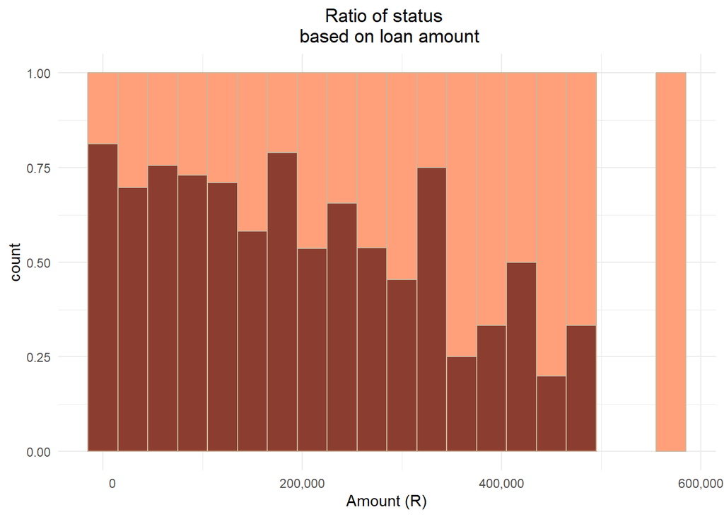

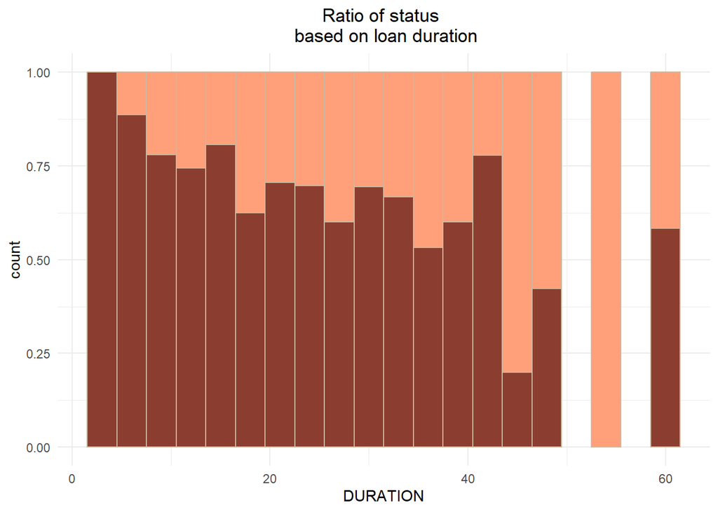

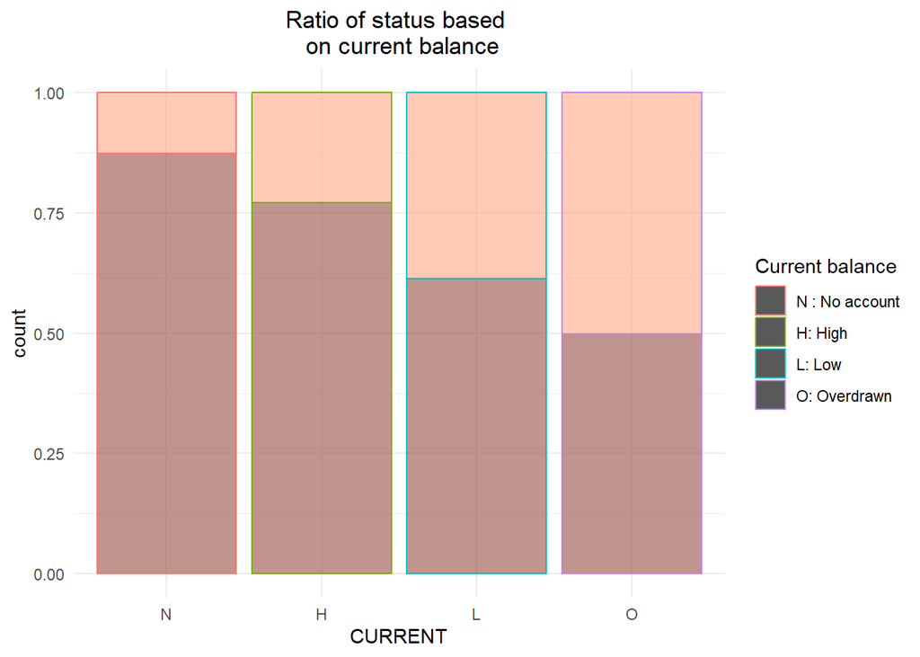

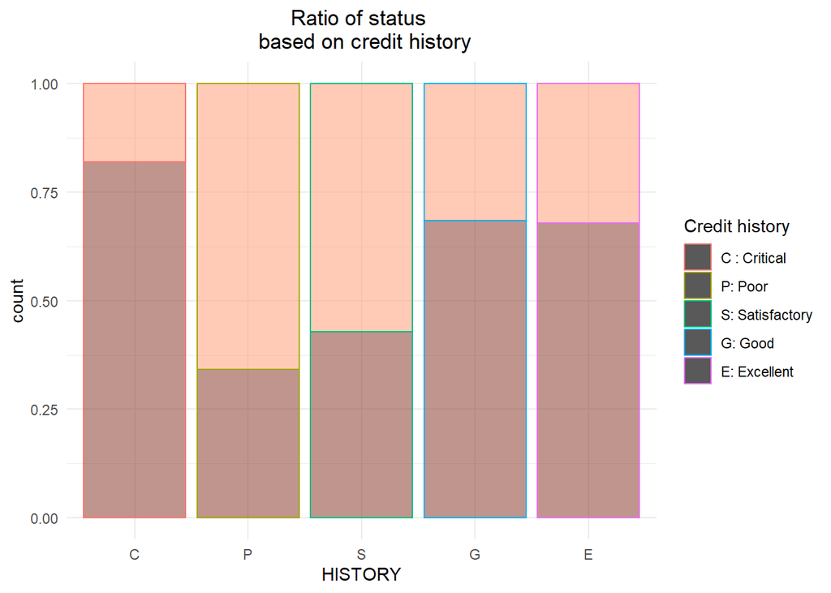

The amount the client received as well the duration in which the loan will be paid back in seems to have the largest effect on weather a client’s status will be seen as “good” or “bad” seeing as the difference in ratios was the largest. The client’s current balance also seems to have a large effect as a clear correlation can be seen as well. The credit history of the client is also identified as being among the most important variables.

[output not shown]

###### *Secondary factors:*

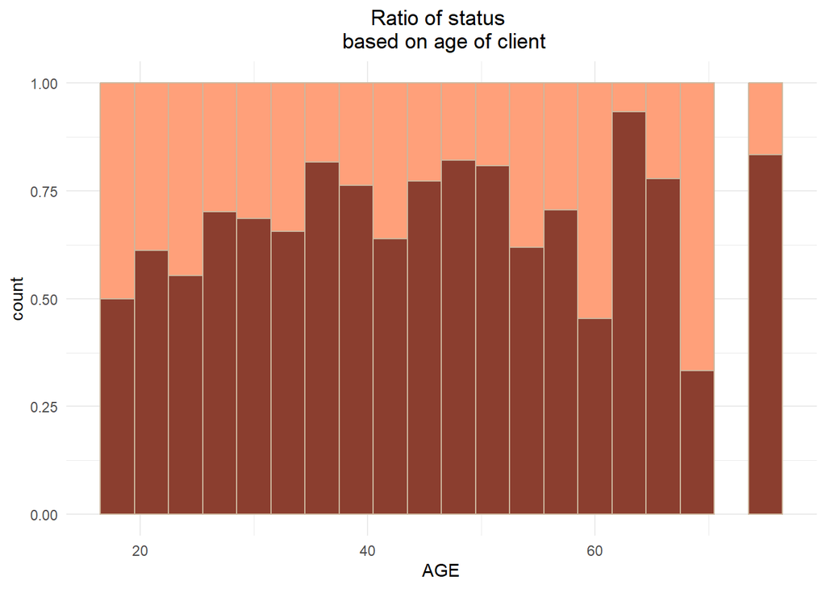

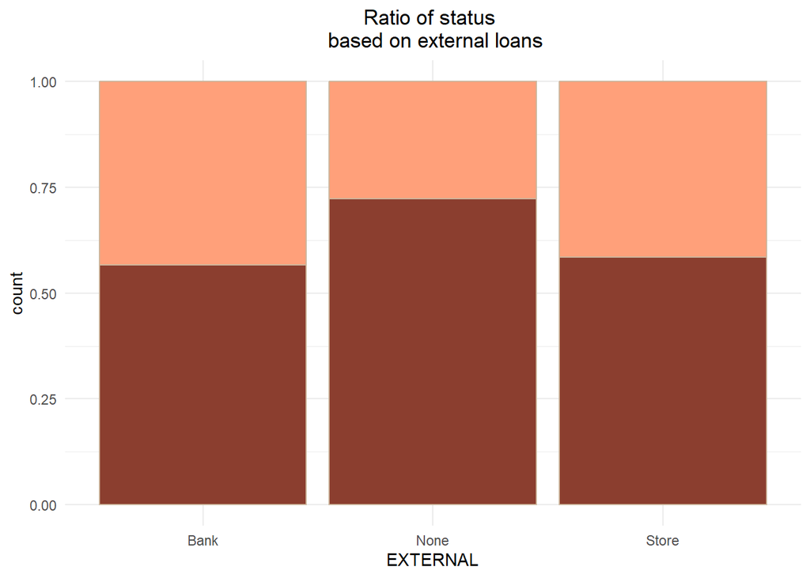

I identified the client’s age as well as weather they have external loans to have an affected but the difference in ratio of the status is lees than the important factors above.

[output not shown]

###### *Possible factors:*

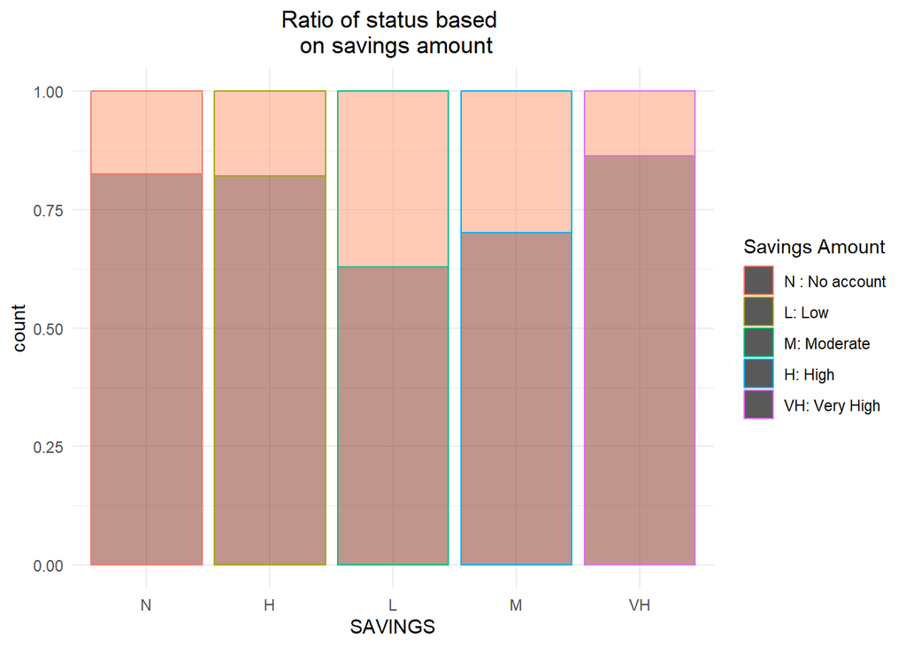

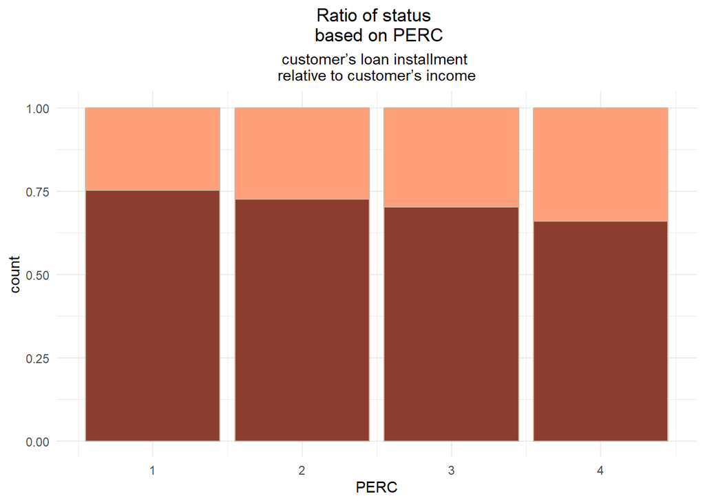

These variables showed a difference in the ratio of the status but the difference was either very small or the is no clear relationship between the variables.

[output not shown]